FFHS DAS Data Science  
Semesterarbeit FS20  
Iwan Imsand

Statistische Datenanalyse (StatDa)  
**Nach der zweiten Präsenz**

# Regressionsanalyse

In diesem Kapitel wird eine Regressionsanalyse druchgeführt.

## Fragestellung

- **Haben die Wetterverhältnisse einen Einfluss auf die Anzahl gefahrener Trips?**
- **Oder: kann aufgrund der Temperatur die Anzahl Trips vorhergesagt werden?**

## Daten für die Analysen

Als Grundlage für nachfolgende Analyse dienen die folgenden Daten:

| Dateiname | Beschreibung |
| --- | --- |
| **`summary-daily-subscribers_only-gender_grouped-citibike-tripweather.parquet`** | Enthält eine nach Geschlecht gruppierte und aggregierte Zusammenfassung pro Tag über alle Jahre. Es wurden nur Jahresmitglieder berücksichtigt! |

Die vorhandenen Merkmale wurden in 1_0_SemArb-StatDa_Deskriptive-Analyse.ipynb eingehender beschrieben, daher wird hier darauf verzichtet.

Alle Dateien befinden sich im Pfad `./../data/citibike/tripdata/`.

```python
import os
import pandas as pd
import numpy as np

import statsmodels.api as sm
from statsmodels.stats.outliers_influence import summary_table
from statsmodels.nonparametric.smoothers_lowess import lowess

import scipy.stats as stats

import matplotlib.pyplot as plt
import matplotlib.gridspec as gridspec

import seaborn as sns
```

```python
%matplotlib inline
```

```python
pd.options.display.float_format = '{:.5f}'.format
```

```python
path_tripdata = './../data/citibike/tripdata'
```

```python
SEED = 10142101
```

```python
tripweather_daily = pd.read_parquet(os.path.join(path_tripdata, 'summary-daily-subscribers_only-gender_grouped-citibike-tripweather.parquet'))
tripweather_daily = tripweather_daily.reset_index().set_index(['Date', 'Gender']).rename(index={'0': 'unknown', '1': 'male', '2': 'female'})
```

Es interessieren nur bestimmte Merkmale die untersucht werden sollen.

```python
tripweather = tripweather_daily[['Trip count', 'Trip Duration mean', 'Trip Duration median', 'Linear Distance mean', 'Linear Distance median', 'temp mean', 'humidity mean', 'wind_speed mean', 'rain_1h sum', 'snow_1h sum']]
```

```python
tripweather.columns
```

```
Index(['Trip count', 'Trip Duration mean', 'Trip Duration median',
       'Linear Distance mean', 'Linear Distance median', 'temp mean',
       'humidity mean', 'wind_speed mean', 'rain_1h sum', 'snow_1h sum'],
      dtype='object')
```

```python
tripweather.head()
```

| Date | Gender | Trip count | Trip Duration mean | Trip Duration median | Linear Distance mean | Linear Distance median | temp mean | humidity mean | wind_speed mean | rain_1h sum | snow_1h sum |
| --- | --- | --- | --- | --- | --- | --- | --- | --- | --- | --- | --- |
| 2013-07-01 | male | 11071.00000 | 808.64547 | 632.00000 | 2.03159 | 1.56735 | 23.79903 | 90.51613 | 2.41839 | 20.27000 | 0.00000 |
|  | female | 2808.00000 | 907.32621 | 740.00000 | 2.04062 | 1.64602 | 23.79903 | 90.51613 | 2.41839 | 20.27000 | 0.00000 |
| 2013-07-02 | unknown | 3.00000 | 706.33333 | 569.00000 | 1.61334 | 1.54844 | 24.74600 | 88.68000 | 2.34080 | 0.90000 | 0.00000 |
|  | male | 14616.00000 | 781.76300 | 623.00000 | 2.01545 | 1.55847 | 24.74600 | 88.68000 | 2.34080 | 0.90000 | 0.00000 |
|  | female | 4022.00000 | 909.02064 | 760.50000 | 2.09052 | 1.70047 | 24.74600 | 88.68000 | 2.34080 | 0.90000 | 0.00000 |

Es soll eine Regressionsanalyse für Männer und Frauen durchgeführt werden, die Beobachtungen ohne Geschlechtsangabe werden nicht berücksichtigt. Daher werden zwei Datensätze erstellt, einer der nur die Beobachtungen der Männer enthält und einer nur die Beobachtungen der Frauen.

### Daten Männer

```python
tripweather_male = tripweather.xs('male', level=1)
```

```python
tripweather_male.describe()
```

|  | Trip count | Trip Duration mean | Trip Duration median | Linear Distance mean | Linear Distance median | temp mean | humidity mean | wind_speed mean | rain_1h sum | snow_1h sum |
| --- | --- | --- | --- | --- | --- | --- | --- | --- | --- | --- |
| count | 2488.00000 | 2488.00000 | 2488.00000 | 2488.00000 | 2488.00000 | 2488.00000 | 2488.00000 | 2488.00000 | 2488.00000 | 2488.00000 |
| mean | 25164.52613 | 706.69569 | 543.80386 | 1.68413 | 1.31245 | 13.11709 | 62.95264 | 3.19217 | 4.28425 | 0.94801 |
| std | 12576.74042 | 78.63251 | 57.65345 | 0.14432 | 0.10020 | 9.67349 | 14.79839 | 1.33719 | 9.60217 | 17.89780 |
| min | 762.00000 | 519.41735 | 379.00000 | 1.18907 | 0.94535 | -13.26792 | 21.54167 | 1.21583 | 0.00000 | 0.00000 |
| 25% | 15468.75000 | 648.39944 | 499.87500 | 1.58686 | 1.24545 | 5.45958 | 51.58173 | 2.34438 | 0.00000 | 0.00000 |
| 50% | 24090.00000 | 707.09689 | 547.00000 | 1.69659 | 1.32827 | 13.18312 | 62.81250 | 2.85833 | 0.20000 | 0.00000 |
| 75% | 33968.00000 | 747.85906 | 579.00000 | 1.78852 | 1.37901 | 22.11437 | 74.33333 | 3.64031 | 3.64000 | 0.00000 |
| max | 59770.00000 | 1310.33733 | 1082.00000 | 2.31321 | 1.81295 | 32.21250 | 97.72000 | 14.42750 | 110.02000 | 857.76000 |

### Daten Frauen

```python
tripweather_female = tripweather.xs('female', level=1)
```

```python
tripweather_female.describe()
```

|  | Trip count | Trip Duration mean | Trip Duration median | Linear Distance mean | Linear Distance median | temp mean | humidity mean | wind_speed mean | rain_1h sum | snow_1h sum |
| --- | --- | --- | --- | --- | --- | --- | --- | --- | --- | --- |
| count | 2488.00000 | 2488.00000 | 2488.00000 | 2488.00000 | 2488.00000 | 2488.00000 | 2488.00000 | 2488.00000 | 2488.00000 | 2488.00000 |
| mean | 8142.99759 | 802.98742 | 635.60410 | 1.74713 | 1.38508 | 13.11709 | 62.95264 | 3.19217 | 4.28425 | 0.94801 |
| std | 4472.32284 | 97.14269 | 78.40358 | 0.17251 | 0.12492 | 9.67349 | 14.79839 | 1.33719 | 9.60217 | 17.89780 |
| min | 92.00000 | 551.67052 | 405.00000 | 1.12874 | 0.92258 | -13.26792 | 21.54167 | 1.21583 | 0.00000 | 0.00000 |
| 25% | 4881.50000 | 726.45064 | 573.00000 | 1.62759 | 1.29641 | 5.45958 | 51.58173 | 2.34438 | 0.00000 | 0.00000 |
| 50% | 7374.00000 | 804.84742 | 638.00000 | 1.76462 | 1.39991 | 13.18312 | 62.81250 | 2.85833 | 0.20000 | 0.00000 |
| 75% | 11367.25000 | 861.95972 | 687.00000 | 1.87476 | 1.47540 | 22.11437 | 74.33333 | 3.64031 | 3.64000 | 0.00000 |
| max | 21538.00000 | 1464.34850 | 1254.50000 | 2.44612 | 2.03156 | 32.21250 | 97.72000 | 14.42750 | 110.02000 | 857.76000 |

## Analyse

### Korrelationsmatrix

Um einen Überblick über die Stärke des Zusammenhangs zweier Merkmale zu erhalten, wird für jedes paar der Korrelationskoeffizient von Bravais-Pearson berechnet und in einer Korrelationsmatrix dargestellt.

#### Männer

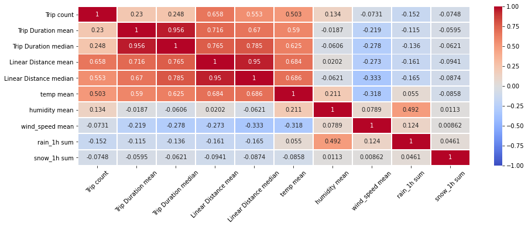

```python
plt.figure(figsize=(15, 5))
corr_mat = sns.heatmap(tripweather_male.corr(method='pearson'), annot=True, fmt='.3g', vmin=-1, vmax=1, center=0, cmap='coolwarm', linecolor='white', linewidths=1, square=False)
_ = plt.xticks(rotation=45)
plt.show()
```

Je rötlicher ein Eintrag ist, desto höher ist der Korrelationskoeffizient und die positive Korrelation ist stärker. Das gleiche gilt umgekehrt für negative Korrelationskoeffizienten, d.h. je bläulicher ein Eintrag ist, desto tiefer ist der Korrelationskoeffizient und die negative Korrelation ist stärker.

Es werden hier die interessanten Korrelationen aufgelistet, welche für die weitere Analyse relevant sind.

- Durchschnittliche Temperatur
  - zur anzahl Trips: **0.50** *(**moderate** Korrelation)*
  - zur durchschnittlichen Dauer: **0.59** *(**moderate** Korrelation)*
  - zum Median der durchschnittlichen Dauer: **0.62** *(**starke** Korrelation)*
  - zur durchschnittlichen Distanz: **0.68** *(**starke** Korrelation)*
  - zum Median der durchschnittlichen Distanz: **0.69** *(**starke** Korrelation)*
- Durchschnittliche Windgeschwindigkeit
  - zur durchschnittlichen Dauer: **-0.22** *(**schwache** Korrelation)*
  - zum Median der durchschnittlichen Dauer: **-0.28** *(**schwache** Korrelation)*
  - zur durchschnittlichen Distanz: **-0.27** *(**schwache** Korrelation)*
  - zum Median der durchschnittlichen Distanz: **-0.33** *(**schwache** Korrelation)*

#### Frauen

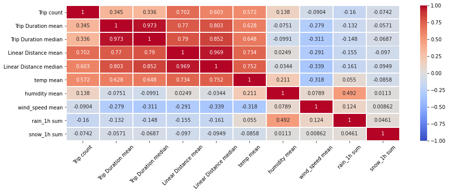

```python
plt.figure(figsize=(15, 5))
corr_mat = sns.heatmap(tripweather_female.corr(method='pearson'), annot=True, fmt='.3g', vmin=-1, vmax=1, center=0, cmap='coolwarm', linecolor='white', linewidths=1, square=False)
_ = plt.xticks(rotation=45)
plt.show()
```

Interessant für die Fragestellung sind folgende Zusammenhänge:

- Durchschnittliche Temperatur
  - zur anzahl Trips: **0.57** *(**moderate** Korrelation)*
  - zur durchschnittlichen Dauer: **0.63** *(**moderate** Korrelation)*
  - zum Median der durchschnittlichen Dauer: **0.65** *(**starke** Korrelation)*
  - zur durchschnittlichen Distanz: **0.73** *(**starke** Korrelation)*
  - zum Median der durchschnittlichen Distanz: **0.75** *(**starke** Korrelation)*
- Durchschnittliche Windgeschwindigkeit
  - zur Durchschnittlichen Dauer: **-0.28** *(**schwache** Korrelation)*
  - zum Median der durchschnittlichen Dauer: **-0.31** *(**schwache** Korrelation)*
  - zur durchschnittlichen Distanz: **-0.29** *(**schwache** Korrelation)*
  - zum Median der durchschnittlichen Distanz: **-0.34** *(**schwache** Korrelation)*

### Streudiagramm

Um die Zusammenhänge graphisch darzustellen, wird ein Scatterplot erstellt. Damit dieser übersichtlich bleibt, werden nur die für die Fragestellung interessanten Merkmale einbezogen, d.h. es wird die Durchschnittliche Temperatur und die Durchschnittliche Windgeschwindigkeit gegen die oben aufgelisteten Merkmale geplottet.

```python
x_col_temp = 'temp mean'
x_col_wind = 'wind_speed mean'
y_cols = ['Trip count', 'Trip Duration mean', 'Trip Duration median', 'Linear Distance mean', 'Linear Distance median']
```

#### Durchschnittliche Temperatur

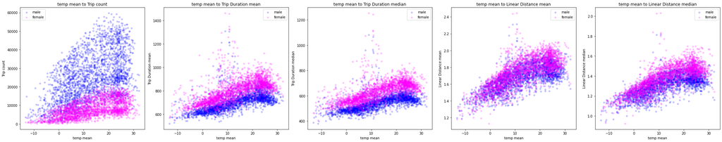

```python
fig = plt.figure(figsize=(30, 6))
gs = gridspec.GridSpec(1, 5, figure=fig)

for idx, col in enumerate(y_cols):
    ax = fig.add_subplot(gs[0, idx])
    ax.set_title(x_col_temp + ' to ' + col)
    _ = tripweather_male.plot(ax=ax, x=x_col_temp, y=col, kind='scatter', alpha=0.2, color='blue', label='male')
    _ = tripweather_female.plot(ax=ax, x=x_col_temp, y=col, kind='scatter', alpha=0.2, color='magenta', label='female')

plt.legend()
fig.tight_layout()
plt.show()
```

Folgendes fällt bei den Plots auf:

- Erste Grafik:
  - Die Männer fahren mehr Trips als die Frauen.
  - Umso höher die Temperatur ist, umso höher ist auch die Anzahl der Trips. Aber es gibt auch Tage die zwar eine hohe Temperatur haben, aber trotzdem werden nicht so viele Trips gefahren.
- Zweite und dritte Grafik:
  - Das Verhalten von Männern und Frauen ist ähnlich, doch machen die Frauen durchschnittlich längere Fahrten.
  - Bei höheren Temperaturen sind die Fahrten länger als bei tieferen.
  - Die länge der Fahrten nimmt aber zwischen 20°C und 30°C wieder kontinuierlich ab.
- Vierte und fünfte Grafik
  - Hier sind Frauen und Männer sehr ähnlich.
  - Auch hier wird die zurückgelegte Distanz länger wenn die Temperatur höher ist.
  - Auch hier scheint die Distanz zwischen 20°C und 30°C zu stagnieren oder sogar etwas abzufallen.

#### Durchschnittliche Windgeschwindigkeit

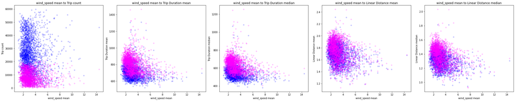

```python
fig = plt.figure(figsize=(30, 6))
gs = gridspec.GridSpec(1, 5, figure=fig)

for idx, col in enumerate(y_cols):
    ax = fig.add_subplot(gs[0, idx])
    ax.set_title(x_col_wind + ' to ' + col)
    _ = tripweather_male.plot(ax=ax, x=x_col_wind, y=col, kind='scatter', alpha=0.2, color='blue')
    _ = tripweather_female.plot(ax=ax, x=x_col_wind, y=col, kind='scatter', alpha=0.2, color='magenta')

fig.tight_layout()
plt.show()
```

Folgendes fällt bei den Plots auf:

- Erste Grafik:
  - Die Männer fahren mehr Trips als die Frauen.
  - Es gibt weniger Trips ab einer Windgeschwindigkeit von ca. 7m/s.
- Zweite und dritte Grafik:
  - Das Verhalten von Männern und Frauen ist ähnlich, doch machen die Frauen durchschnittlich längere Fahrten.
  - Es ist nicht ein linearer Zusammenhang erkennbar.
- Vierte und fünfte Grafik
  - Hier sind Frauen und Männer sehr ähnlich.
  - Ein linearer Zusammenhang ist nicht erkennbar.

**Die durchschnittliche Windgeschwindigkeit wird nicht mehr weiterverfolgt da hier kein linearer Zusammenhang ersichtlich ist.**

### Lineares Modell - Ordinary Least Squares

Es wird ein lineares Modell erstellt.

```python
ps_male = {}
ps_female = {}
```

```python
for col in y_cols:
    # https://datatofish.com/statsmodels-linear-regression/
    # P value is statistically significatn! (see https://de.wikipedia.org/wiki/Statistische_Signifikanz)
    ps_male[col] = sm.OLS(tripweather_male[col], sm.add_constant(tripweather_male[x_col_temp])).fit()
    ps_female[col] = sm.OLS(tripweather_female[col], sm.add_constant(tripweather_female[x_col_temp])).fit()
```

Die folgenden Plots zeigen wie gut das lineare Modell auf die Daten passt.

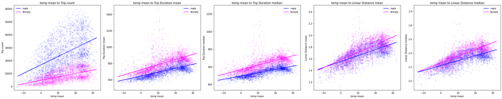

```python
fig = plt.figure(figsize=(30, 6))
gs = gridspec.GridSpec(1, 5, figure=fig)

for idx, col in enumerate(y_cols):
    ax = fig.add_subplot(gs[0, idx])
    ax.set_title(x_col_temp + ' to ' + col)
    _ = tripweather_male.plot(ax=ax, x=x_col_temp, y=col, kind='scatter', alpha=0.07, color='blue')
    _ = tripweather_female.plot(ax=ax, x=x_col_temp, y=col, kind='scatter', alpha=0.07, color='magenta')
    _ = ax.plot(tripweather_male[x_col_temp], ps_male[col].predict(sm.add_constant(tripweather_male[x_col_temp])), color='blue', label='male')
    _ = ax.plot(tripweather_female[x_col_temp], ps_female[col].predict(sm.add_constant(tripweather_female[x_col_temp])), color='magenta', label='female')
    ax.legend()

fig.tight_layout()
plt.show()
```

Es ist ersichtlich, dass hier nur eine Gerade darübergelegt wurde und somit z.B. in der zweiten Grafik von Links, der Abstieg, der bei etwas über 20°C beginnt, nicht berücksichtigt wird. Aber ansonsten passt die Linie nicht schlecht für eine Vorhersage, wie lange die Trips dauern werden, bei einer bestimmten Temperatur.

Bei der Anzahl der Trips könnte man sagen, dass die Linie bei den Frauen gut passt, aber bei den Männern doch eine recht grosse Abweichung vorhanden ist.

### Analyse des Modells

Hier wird das Modell zur Vorhersage der Anzahl Trips aufgrund der Temperatur analysiert. Es wird nur das Modell mit den Frauen näher analyisert.

Hier das Summary des Modells zu den Frauen.

```python
print(ps_female['Trip count'].summary())
```

```
                            OLS Regression Results
==============================================================================
Dep. Variable:             Trip count   R-squared:                       0.327
Model:                            OLS   Adj. R-squared:                  0.327
Method:                 Least Squares   F-statistic:                     1210.
Date:                Sun, 21 Jun 2020   Prob (F-statistic):          2.66e-216
Time:                        14:05:14   Log-Likelihood:                -23950.
No. Observations:                2488   AIC:                         4.790e+04
Df Residuals:                    2486   BIC:                         4.792e+04
Df Model:                           1
Covariance Type:            nonrobust
==============================================================================
                 coef    std err          t      P>|t|      [0.025      0.975]
------------------------------------------------------------------------------
const       4673.5254    123.942     37.707      0.000    4430.484    4916.566
temp mean    264.5001      7.605     34.779      0.000     249.587     279.413
==============================================================================
Omnibus:                      111.217   Durbin-Watson:                   0.449
Prob(Omnibus):                  0.000   Jarque-Bera (JB):               82.062
Skew:                           0.347   Prob(JB):                     1.52e-18
Kurtosis:                       2.442   Cond. No.                         27.5
==============================================================================

Warnings:
[1] Standard Errors assume that the covariance matrix of the errors is correctly specified.
```

Folgendes ist zu den Resultaten zu sagen:

**Oben links:**

- `Dep. Variable`: die abhängige Variable, im vorliegenden Fall `Trip count`.
- `Model`: das verwendete Modell, OLS -> Ordinary Least Squares
- `Method`: Die Parameter des Modells werden mit der Least Squares Methode ermittelt.
- `No. Observations`: Anzahl Beobachtungen
- `Df Residuals`: $n-p-1$, d.h. Anzahl Beobachtungen minus Anzahl Parameter minus die Konstante ($n-p$ wenn keine Konstante verwendet wird). Hier wurde mit `temp mean` ein parameter verwendet und eine Konstante, daher die Anzahl der Beobachtungen minus 2.
- `Df Model`: Anzahl Freiheitsgrade, da wir eine Einflussgrösse mit `temp mean` haben, ist dieser Wert 1 (die Konstante wird hier nicht gezählt)
- `Covariance Type`: `nonrobust` heisst, das der Kovarianz-Schätzer, der in den Resultaten benutzt wird, nicht gegen Ausreisser geschützt ist.

**Oben rechts:**

- `R-squared`: Der Wert $0.327$ sagt aus, dass 32.7% der Beobachtungen zum Regressionsmodell passen. Umso höher dieser Wert, umso besser passt das Regressionsmodell auf die Beobachtungen. (In manchen Fällen ist aber ein hoher Wert nicht automatisch auch ein Hinweis auf ein gutes Regressionsmodell!) Der vorliegende Wert ist nicht sehr hoch, aber es war schon in dem Plot mit der darübergelegten Geraden zu erkennen, dass unser Modell nicht ganz auf die Beobachtungen passt.
- `Adj. R-squared`: Berücksichtigt auch die Anzahl der unabhängigen Parameter, in vorliegenden Fall also ein Parameter `temp mean`.
- `F-statistics`: Der Wert $1210$ sagt aus, dass das Modell statistisch signifikant ist und $H_0$ somit verworfen wird. Mindestens eine Variable hat also einen Einfluss auf das Modell. Die Nullhypothese $H_0$ sagt aus, dass alle erklärenden Variablen keinen Einfluss auf die abhängige Variable haben. Hierbei ist $H_0: \beta_1=\beta_2=...=\beta_k=0 \Rightarrow$ und $H_1: \beta_j\neq0$ für mindestens ein $j \in \{1,...,k\}$. (Der Wert kann ermittelt werden durch `ps_female['Trip count'].mse_model / ps_female['Trip count'].mse_resid`, $F=\dfrac{MS_{explained}}{MS_{residual}}$)
- `Prob (F-statistic)`: Hier ist der Wert mit 2.66e-216 extrem klein. Die Wahrscheinlichkeit das die Nullhypothese wahr ist und wir einen Fehler I.Art begehen, ist also verschwindend klein.
- `Log-Likelihood`: Wenn nur ein Modell angeschaut wird, ist der Wert nicht so wichtig. Erst wenn man ein alternatives Modell hat, kann man diesen Wert für einen Vergleich nutzen. Da hier so viele Daten vorhanden sind (2488), ist der Wert sehr klein. (Für die lokelihood function, siehe https://en.wikipedia.org/wiki/Likelihood_function und für den Vergleich https://en.wikipedia.org/wiki/Likelihood-ratio_test)
- `AIC`: Passt log-likelihood basierend auf der Anzahl der Beobachtungen und der Komplexität des Modells an. (siehe https://en.wikipedia.org/wiki/Akaike_information_criterion)
- `BIC`: Ähnlich wie AIC, hat jedoch eine höhere Strafe für Modelle mit mehr Parametern. (siehe https://en.wikipedia.org/wiki/Bayesian_information_criterion)

**Mitte:** Hier werden Aussagen zu den Koeffizienten gemacht.

- `coef`: Das zugrundeliegende Modell lautet $y=f(x)=a+b \cdot x$ und in dieser Spalte sind die berechneten Werte angegeben, d.h. eingesetzt lautet das Modell $y=f(x)=4673.5254+264.5001 \cdot x$. Mit diesem können Vorhersagen getroffen werden für y (Anzahl der Trips), wenn für x (temp mean) ein Wert eingesetzt wird. Die Koeffizienten geben den Achsenabschnitt und die Steigung der Regressionsgeraden an.
- `std err`: Der Standardfehler misst, wie präzise das Modell den Unbekannten Wert schätzt. Je kleiner der Standardfehler, desto genauer ist der Schätzwert.
- `t`: Der t-Wert berechnet aus `coef` dividiert durch `std err`
- `P>|t|`: Der p-Wert aus der t-Statistik. Beide Werte sind kleiner als 0.05, dies beduetet, dass die Koeffizienten sich signifikant von 0 unterscheiden. Die Nullhypothese die besagt, dass ein Koeffizient null ist, wird verworfen.
- `[0.025`: Untere Grenze des 95% Konfidenzintervalls
- `0.975]`: Obere Grenze des 95% Konfidenzintervalls

**Unten:** Hier werden Aussagen zu den Residuen gemacht.

- `Omnibus`: D'Angostino's test. (Die Werte erhält man auch mit `sm.stats.omni_normtest(ps_female['Trip count'].resid)`)
- `Prob(Omnibus)`: Die Wahrscheinlichkeit das die Nullhypothese wahr ist und wir einen Fehler I. Art begehen, wenn wir die Nullhypothese verwerfen.
- `Skew`: Schiefe, mit einem Wert von 0.347 ist die Verteilung leicht rechtsschief (oder linkssteil), die Häufung der Werte liegt links. (Den Wert erhält man auch mit `ps_female['Trip count'].resid.skew()`.)
- `Kurtosis`: Wölbung, mit einem Wert von 2.442 sind die Schwänze kürzer und dünner, der zentrale Peak ist oft niedriger und breiter als bei einer Normalverteilung. (**ACHTUNG**: Pearson's Definition! Mit `ps_female['Trip count'].resid.kurt()` erhält man einen anderen Wert, nämlich -0.5567 und nicht den hier angegebenen Wert von 2.442! Der Grund ist, dass die Kurtosis in den OLS Regression Results mit der Pearson's Definition berechnet wird (normal $\approx$ 3.0) und nicht mit der Fisher's Definition (normal $\approx$ 0.0), um auf den gleichen Wert zu kommen, muss man also folgendes ausführen: `ps_female['Trip count'].resid.kurt() + 3` - einfach mit 3 addieren. Oder eine andere Library nutzen, die direkt die Pearson's Definition nutzt und diese nicht noch mit -3 justiert.)
- `Durbin-Watson`: Ein weiterer Test der überprüft, ob die Korrelation zwischen zwei aufeinanderfolgenden Residualgrössen bei einer Regressionsanalyse ungleich null ist. Hierzu gibt es z.B. die Tabelle https://www.real-statistics.com/statistics-tables/durbin-watson-table/, aufgrund derer die Schranken ermittelt werden können, um eine Aussage über die Entscheidung machen zu können. Für n=2000, k=1 und $\alpha$ ist $dl=1.925$ und $du=1.927$. Aktuell ist aber n=2488, da aber der Wert mit 0.449 immer noch stark unter der Schranke von $dl=1.925$ liegt, kann angenommen werden das wir eine positive Autokorrelation haben (siehe Angewandte Statistik, Abbildung 7.32, Seite 789). (Es wurde ein Test durchgeführt und nur die ersten 2000 Tage vom Datensatz `tripweather_female` in die Regression einbezogen, der Wert ist dann 0.453, also die gleiche Schlussfolgerung: positive Autokorrelation). (Den Wert erhält man auch mit `sm.stats.stattools.durbin_watson(ps_female['Trip count'].resid)`.)
- `Jargue-Bera (JB)`: Statistischer Test, der anhand von Schiefe und Kurtosis prüft, ob eine Normalverteilung vorliegt. Mit einem Wert von 82.062 wird $H_0$ verworfen, es liegt also keine Normalverteilung vor. (Die Werte erhält man auch mit `sm.stats.stattools.jarque_bera(ps_female['Trip count'].resid)`, es wird auch Skew und Kurtosis ausgegeben.)
- `Prob(JB)`: Wahrscheinlichkeit die besagt, dass wir $H_0$ beim Jarque-Bera Test, verwerfen und damit einen Fehler I.Art begehen. Die Wahrscheinlichkeit ist sehr klein, wir können also davon ausgehen dass wir $H_0$ zurecht verworfen haben.
- `Cond. No.`: Dieser Wert zeigt, ob unabhängige Variablen miteinander korrelieren (Multicollinearity). Hier haben wir mit `temp mean` nur eine unabhängige Variable, also ist dieser Wert aktuell nicht relevant.

### Plot der Daten, der Gerade und den Konfidenzintervallen

Im nächsten Plot sind die Daten mit der Geraden zur Vorhersage und den Konfidenzintervallen zu sehen.

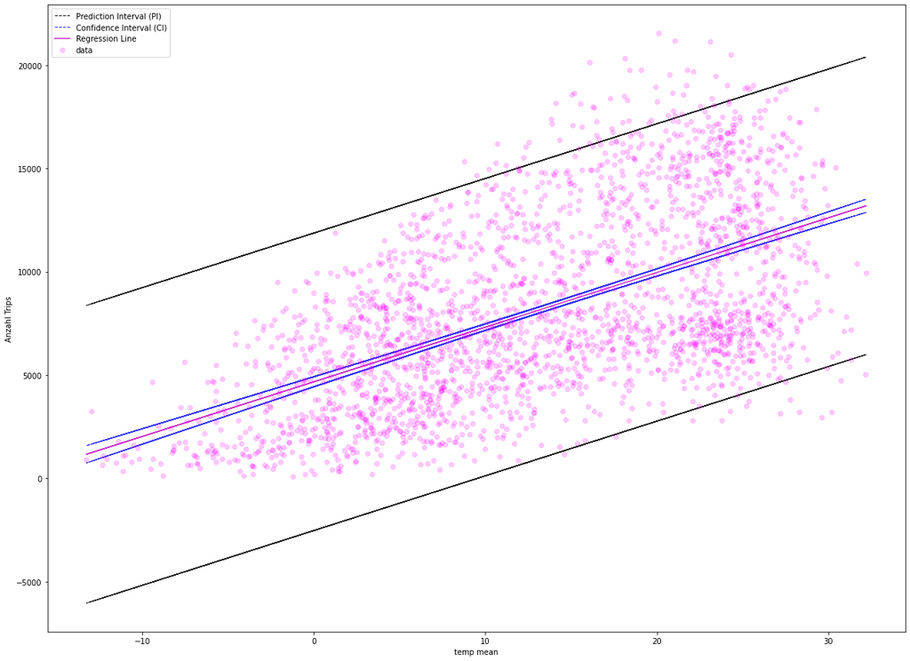

```python
x = tripweather_female['temp mean']
y = tripweather_female['Trip count']
ols_fit = ps_female['Trip count']

# carry out yr fit

# ols cinv
st, data, ss2 = summary_table(ols_fit, alpha=0.05)

fittedvalues = data[:,2]
predict_mean_se  = data[:,3]
predict_mean_ci_low, predict_mean_ci_upp = data[:,4:6].T
predict_ci_low, predict_ci_upp = data[:,6:8].T


fig, ax = plt.subplots(figsize=(20,15))

cil, = ax.plot(x,predict_ci_low, 'k--', lw=1, alpha=0.9, label='Prediction Interval (PI)')
ciu, = ax.plot(x,predict_ci_upp, 'k--', lw=1, alpha=0.9)
mcil, = ax.plot(x,predict_mean_ci_low, 'b--', lw=1, alpha=0.8, label='Confidence Interval (CI)')
mciu, = ax.plot(x,predict_mean_ci_upp, 'b--', lw=1, alpha=0.8)

ax.plot(x, ps_female['Trip count'].predict(sm.add_constant(tripweather_female['temp mean'])), 'm-', label="Regression Line", alpha= 0.8)

ax.plot(x, y, 'o', label="data", color='magenta', alpha=0.2)

#ax.fill_between(x , predict_mean_ci_low, predict_mean_ci_upp)

ax.legend(loc='best');
ax.set_xlabel('temp mean')
ax.set_ylabel('Anzahl Trips')

plt.show()
```

- Das Konfidenzintervall (CI) sagt aus, dass mit 95%-iger Wahrscheinlichkeit die wahre Gerade zwischen diesem Intervall liegt.
- Das Konfidenzintervall für die Vorhersage (PI) sagt aus, dass wenn wir einen Wert vorhersagen, der wahre Wert mit 95%-iger Wahrscheinlichkeit zwischen diesem Intervall liegt.

Die Gerade hat ein kleines Konfidenzintervall. Doch wenn man Vorhersagen macht, ist das Konfidenzintervall sehr breit und die Vorhersagen nicht sehr genau.

### Residuenanalyse

#### Histogramm der Residuen

In folgendem Plot ist ein Histogramm der Residuen zu sehen.

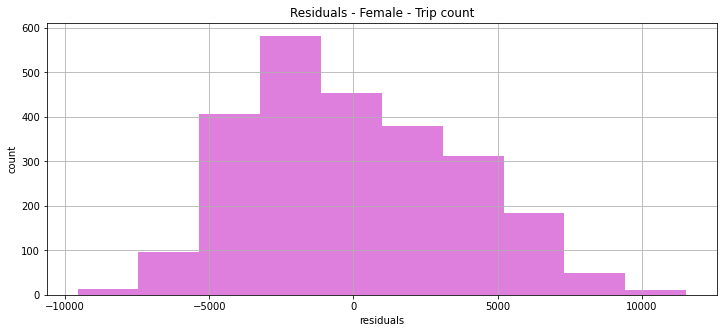

```python
fig = plt.figure(figsize=(12,5))
_=ps_female['Trip count'].resid.hist(color='m', alpha=0.5)
plt.xlabel('residuals')
plt.ylabel('count')
plt.title('Residuals - Female - Trip count')
plt.show()
```

#### Dichtefunktion der Residuen im Vergleich zu einer Dichtefunktion der Normalverteilung

Im nächsten Plot wurde noch die Dichtefunktion der Residuen sowie die Dichtefunktion der Normalverteilung (rot) hinzugefügt. Es ist ersichtlich, dass die Verteilung rechsschief (oder linkssteil) ist. Auf der linken Seite sieht man, dass der Schwanz der Residuen kürzer und dünner ist als bei der Normalverteilung.

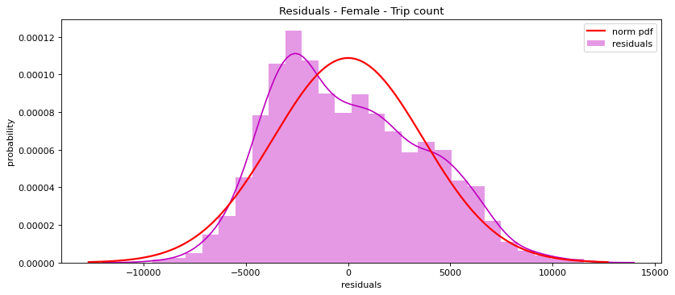

```python
fig = plt.figure(figsize=(12,5), dpi=80)
ax = sns.distplot(ps_female['Trip count'].resid, label='residuals', color='m')

x_norm = np.arange(-ps_female['Trip count'].resid.max()*1.1, ps_female['Trip count'].resid.max()*1.1, 1)
y_norm = stats.norm.pdf(x_norm, scale=ps_female['Trip count'].resid.std(), loc=ps_female['Trip count'].resid.mean())
ax.plot(x_norm, y_norm, 'r', lw=2, label='norm pdf')

plt.xlabel('residuals')
plt.ylabel('probability')
plt.title('Residuals - Female - Trip count')

ax.legend()
plt.show()
```

### Regression Diagnostic Plots

Eine sehr gute Anleitung wie die Plots von R auch in Python erstellt werden können, ist hier zu finden: https://towardsdatascience.com/going-from-r-to-python-linear-regression-diagnostic-plots-144d1c4aa5a. Und eine Erklärung für die Interpretation dieser Plots ist zu finden unter https://data.library.virginia.edu/diagnostic-plots/.

```python
def reg_diag_plot(results, edgecolor='k', facecolor='None', alpha=0.8):

    fig, axs = plt.subplots(nrows=2, ncols=2, figsize=(25,18))


    # Residuals vs.Fitted

    ax = axs[0,0]

    residuals = results.resid
    fitted = results.fittedvalues
    smoothed = lowess(residuals,fitted)
    top3 = abs(residuals).sort_values(ascending = False)[:5]

    ax.scatter(fitted, residuals, edgecolor=edgecolor, facecolor=facecolor, alpha=alpha)
    ax.plot(smoothed[:,0],smoothed[:,1],color = 'r', lw=2)
    ax.set_ylabel('Residuals')
    ax.set_xlabel('Fitted Values')
    ax.set_title('Residuals vs. Fitted')
    ax.plot([min(fitted),max(fitted)],[0,0],color = 'k',linestyle = '--', alpha = .3, lw=2)

    for i in top3.index:
        #ax.annotate(i,xy=(fitted[i],residuals[i]))
        pass


    # QQ-Plot

    ax = axs[0,1]

    sorted_student_residuals = pd.Series(results.get_influence().resid_studentized_internal)
    sorted_student_residuals.index = results.resid.index
    sorted_student_residuals = sorted_student_residuals.sort_values(ascending = True)
    df = pd.DataFrame(sorted_student_residuals)
    df.columns = ['sorted_student_residuals']
    df['theoretical_quantiles'] = stats.probplot(df['sorted_student_residuals'], dist = 'norm', fit = False)[0]
    rankings = abs(df['sorted_student_residuals']).sort_values(ascending = False)
    top3 = rankings[:3]

    x = df['theoretical_quantiles']
    y = df['sorted_student_residuals']
    ax.scatter(x,y, edgecolor = edgecolor, facecolor = facecolor, alpha=alpha)
    ax.set_title('Normal Q-Q')
    ax.set_ylabel('Standardized Residuals')
    ax.set_xlabel('Theoretical Quantiles')
    ax.plot([np.min([x,y]),np.max([x,y])],[np.min([x,y]),np.max([x,y])], color = 'r', ls = '--')

    for val in top3.index:
        #ax.annotate(val,xy=(df['theoretical_quantiles'].loc[val],df['sorted_student_residuals'].loc[val]))
        pass


    # Scale-Location

    ax = axs[1,0]

    student_residuals = results.get_influence().resid_studentized_internal
    sqrt_student_residuals = pd.Series(np.sqrt(np.abs(student_residuals)))
    sqrt_student_residuals.index = results.resid.index
    smoothed = lowess(sqrt_student_residuals,fitted)
    top3 = abs(sqrt_student_residuals).sort_values(ascending = False)[:3]

    ax.scatter(fitted, sqrt_student_residuals, edgecolors = edgecolor, facecolors = facecolor, alpha=alpha)
    ax.plot(smoothed[:,0],smoothed[:,1],color = 'r', lw=2)
    ax.set_ylabel('$\sqrt{|Studentized \ Residuals|}$')
    ax.set_xlabel('Fitted Values')
    ax.set_title('Scale-Location')
    ax.set_ylim(0,max(sqrt_student_residuals)+0.1)

    for i in top3.index:
        #ax.annotate(i,xy=(fitted[i],sqrt_student_residuals[i]))
        pass


    # Residuals vs. Leverage

    ax = axs[1, 1]

    student_residuals = pd.Series(results.get_influence().resid_studentized_internal)
    student_residuals.index = results.resid.index
    df = pd.DataFrame(student_residuals)
    df.columns = ['student_residuals']
    df['leverage'] = results.get_influence().hat_matrix_diag
    smoothed = lowess(df['student_residuals'],df['leverage'])
    sorted_student_residuals = abs(df['student_residuals']).sort_values(ascending = False)
    top3 = sorted_student_residuals[:3]

    x = df['leverage']
    y = df['student_residuals']
    xpos = max(x)+max(x)*0.01
    ax.scatter(x, y, edgecolors = edgecolor, facecolors = facecolor, alpha=alpha)
    ax.plot(smoothed[:,0],smoothed[:,1],color = 'r', lw=2)
    ax.set_ylabel('Studentized Residuals')
    ax.set_xlabel('Leverage')
    ax.set_title('Residuals vs. Leverage')
    ax.set_ylim(y.min()*1.1, y.max()*1.1)
    ax.set_xlim(0, x.max()*1.1)
    plt.tight_layout()
    for val in top3.index:
        #ax.annotate(val,xy=(x.loc[val],y.loc[val]))
        pass

    cooksx = np.linspace(min(x), xpos, 50)
    p = len(results.params)
    poscooks1y = np.sqrt((p*(1-cooksx))/cooksx)
    poscooks05y = np.sqrt(0.5*(p*(1-cooksx))/cooksx)
    negcooks1y = -np.sqrt((p*(1-cooksx))/cooksx)
    negcooks05y = -np.sqrt(0.5*(p*(1-cooksx))/cooksx)

    ax.plot(cooksx,poscooks1y,label = "Cook's Distance", ls = ':', color = 'r', lw=2)
    ax.plot(cooksx,poscooks05y, ls = ':', color = 'r')
    ax.plot(cooksx,negcooks1y, ls = ':', color = 'r')
    ax.plot(cooksx,negcooks05y, ls = ':', color = 'r')
    ax.plot([0,0],ax.get_ylim(), ls="--", alpha = .3, color = 'k', lw=2)
    ax.plot(ax.get_xlim(), [0,0], ls="--", alpha = .3, color = 'k', lw=2)
    #ax.annotate('1.0', xy = (xpos, poscooks1y[-1]), color = 'r')
    #ax.annotate('0.5', xy = (xpos, poscooks05y[-1]), color = 'r')
    #ax.annotate('1.0', xy = (xpos, negcooks1y[-1]), color = 'r')
    #ax.annotate('0.5', xy = (xpos, negcooks05y[-1]), color = 'r')
    #ax.legend()

    plt.show()
```

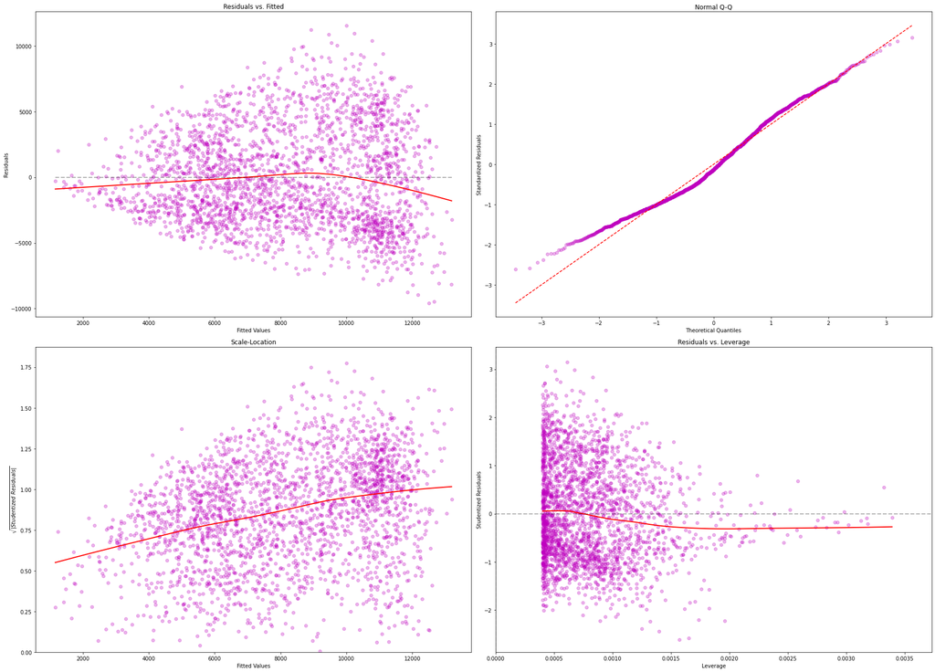

```python
reg_diag_plot(ps_female['Trip count'], edgecolor='m', facecolor='m', alpha=0.3)
```

**Erster Plot oben Links, "Residuals vs. Fitted":**

- Hier sind die Residuen ersichtlich, d.h. der Fehler der gegenüber dem wahren Wert existiert.
- Die Punkte verteilen sich fast gleichmässig oben und unten, d.h. anhand der roten Linie ist ersichtlich, dass sich links die Werte mehr unter 0 befinden, in der Mitte ist es fast ausgeglichen und rechts dann wieder unter 0. Grundsätzlich kann man aber sagen, dass ein linearer Zusammenhang besteht.
- Umso mehr das man sich nach rechts bewegt, umso mehr steigt die Varianz der Residuen.

**Zweiter Plot oben rechts, "Normal Q-Q":**

- Am besten wäre wenn hier die rote Linie horizontal durch den Plot führt und die Pukte gleichmässig verteilt wären.
- Es ist ersichtlich, dass die Residuen weiter rechts mehr verteilt sind und die rote Linie dadurch nicht horizontal ist, sondern eine Steigung aufweist, es ist ein Aufwärtstrend ersichtlich.
- Dies ist vergleichbar mit dem 1. Plot in welchem die Varianz der Residuen gegen rechts breiter wird.

**Vierter plot unten rechts, "Residuals vs. Leverage":**

- Leverage bedeutet 'Hebelwirkung' und beschreibt allgemein Situationen, bie denen kleine Änderungen einer Variablen zu grossen Ausschlägen im Resultat führt. Dieser Plot zeigt Werte die starke Einflüsse auf die Regressionslinie haben könnten.
- Werte in den Ecken oben rechts oder unten rechts sind Hinweise auf Werte die stark auf die Regressionslinie einwirken und bei Entfernung evtl. ein besseres Modell liefern könnten.
- Im Plot fallen keine solchen Werte auf.
- Da keine sehr auffälligen Werte vorhanden sind, ist im Plot die 'Cook's distance' Begrenzung nicht ersichtlich. Wären aber Werte nahe oder ausserhalb dieser Begrenzung vorhanden, wären dies Werte die entfernt werden sollten, da sie eine sehr starke Wirkung auf das Resultat hätten.

### Boxplot der Residuen nach Jahren gruppiert

Es interessiert mich noch wie die Lage und Streuung der Residuen für jedes Jahr aussieht. Dazu wird ein Boxplot für jedes Jahr erstellt.

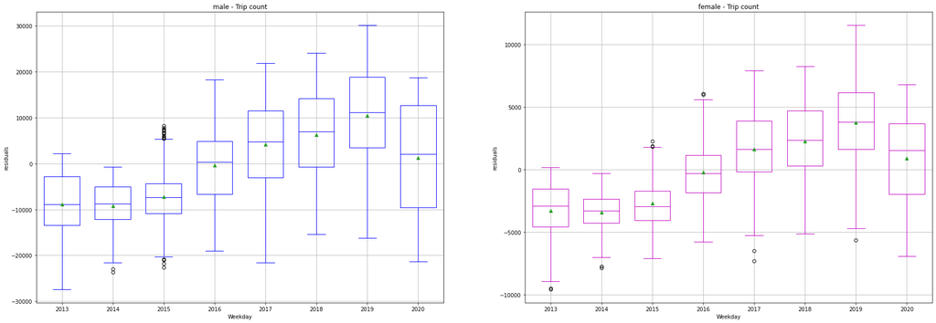

```python
data_male = (
    ps_male['Trip count'].resid
        .reset_index()
        .set_index(ps_male['Trip count'].resid.index.year)
        .drop(columns='Date')
        .reset_index()
        .rename(columns={0: 'resid'})
        .pivot(columns='Date', values='resid')
        .apply(lambda x: pd.Series(x.dropna().values))
)

data_female = (
    ps_female['Trip count'].resid
        .reset_index()
        .set_index(ps_female['Trip count'].resid.index.year)
        .drop(columns='Date')
        .reset_index()
        .rename(columns={0: 'resid'})
        .pivot(columns='Date', values='resid')
        .apply(lambda x: pd.Series(x.dropna().values))
)

fig, (ax_male, ax_female) = plt.subplots(nrows=1, ncols=2, figsize=(30, 10), sharey=False)

data_male.boxplot(ax=ax_male, vert=True, widths=0.7, showmeans=True, showfliers=True, color='b')
data_female.boxplot(ax=ax_female, vert=True, widths=0.7, showmeans=True, showfliers=True, color='m')

ax_male.set_ylabel('residuals')
ax_male.set_xlabel('Weekday')
ax_male.set_title('male - Trip count')

ax_female.set_ylabel('residuals')
ax_female.set_xlabel('Weekday')
ax_female.set_title('female - Trip count')

plt.show()
```

## Regressionsananlyse im Jahr 2014

Aufgrund der Erkenntnisse, dass die Spannweite und Streuung der Residuen im Jahr 2014 am kleinsten sind, wird hier noch ein Modell erstellt und analyisert das nur die Daten des Jahres 2014 berücksichtigt.

**Es werden hier aber keine grösseren Beschreibungen/Analysen mehr durchgeführt! Auch macht es nicht viel Sinn, für zukünftige Vorhersagen, nur die Daten von 2014 zu berücksichtigen. Aber es interessiert wie sich die Plots und die Tests gegenüber dem oben erstellten Modell verhalten.**

### Streudiagramm Jahr 2014

[figure not shown]

```python
fig, ax = plt.subplots(figsize=(10, 8))

_ = tripweather_male[tripweather_male.index.year == 2014].plot(ax=ax, x='temp mean', y='Trip count', kind='scatter', alpha=0.6, color='blue', label='female')
_ = tripweather_female[tripweather_female.index.year == 2014].plot(ax=ax, x='temp mean', y='Trip count', kind='scatter', alpha=0.6, color='magenta', label='female')


ax.set_title('Year 2014')

plt.legend()
fig.tight_layout()
plt.show()
```

Das Streudiagramm sieht dem Streudiagramm über alle Jahre (ganz am Anfang der Regressionsanalyse) sehr ähnlich.

### Lineares Modell und Analyse

```python
tripweather_female_2014 = tripweather_female[tripweather_female.index.year == 2014]
```

```python
ps_female_2014 = sm.OLS(tripweather_female_2014['Trip count'], sm.add_constant(tripweather_female_2014['temp mean'])).fit()
```

Es folgt die Zusammenfassung des Modells:

```python
print(ps_female_2014.summary())
```

```
                            OLS Regression Results
==============================================================================
Dep. Variable:             Trip count   R-squared:                       0.724
Model:                            OLS   Adj. R-squared:                  0.723
Method:                 Least Squares   F-statistic:                     950.7
Date:                Sun, 21 Jun 2020   Prob (F-statistic):          2.04e-103
Time:                        14:05:17   Log-Likelihood:                -3095.8
No. Observations:                 365   AIC:                             6196.
Df Residuals:                     363   BIC:                             6203.
Df Model:                           1
Covariance Type:            nonrobust
==============================================================================
                 coef    std err          t      P>|t|      [0.025      0.975]
------------------------------------------------------------------------------
const       2197.9658     97.020     22.655      0.000    2007.173    2388.758
temp mean    189.3206      6.140     30.833      0.000     177.246     201.395
==============================================================================
Omnibus:                       28.123   Durbin-Watson:                   1.314
Prob(Omnibus):                  0.000   Jarque-Bera (JB):               32.499
Skew:                          -0.719   Prob(JB):                     8.77e-08
Kurtosis:                       3.259   Cond. No.                         25.1
==============================================================================

Warnings:
[1] Standard Errors assume that the covariance matrix of the errors is correctly specified.
```

- Hier fällt z.B. auf, dass 72% der Beobachtungen zum Regressionsmodell passen.
- Auch ist der Log-Likelihood Werte nun viel höher als im alten Modell.
- Es sind mit nur 365 Beobachtungen viel weniger vorhanden als im oberen Modell.
- Die Konfidenzintervalle sind etwas kleiner geworden.

### Plot der Daten, der Gerade und den Konfidenzintervallen

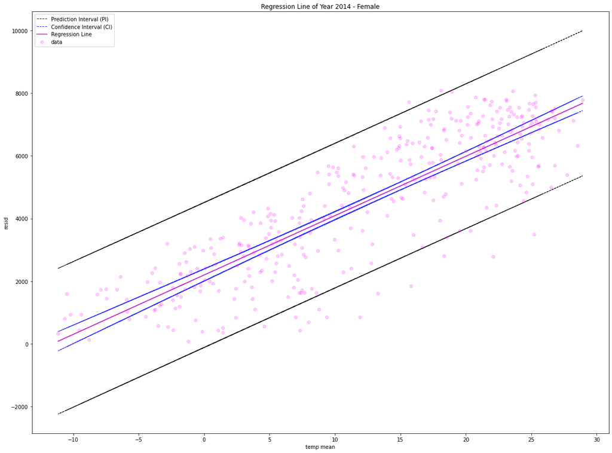

```python
x = tripweather_female_2014['temp mean']
y = tripweather_female_2014['Trip count']
ols_fit = ps_female_2014

# carry out yr fit

# ols cinv
st, data, ss2 = summary_table(ols_fit, alpha=0.05)

fittedvalues = data[:,2]
predict_mean_se  = data[:,3]
predict_mean_ci_low, predict_mean_ci_upp = data[:,4:6].T
predict_ci_low, predict_ci_upp = data[:,6:8].T


fig, ax = plt.subplots(figsize=(20,15))

cil, = ax.plot(x,predict_ci_low, 'k--', lw=1, alpha=0.9, label='Prediction Interval (PI)')
ciu, = ax.plot(x,predict_ci_upp, 'k--', lw=1, alpha=0.9)
mcil, = ax.plot(x,predict_mean_ci_low, 'b--', lw=1, alpha=0.8, label='Confidence Interval (CI)')
mciu, = ax.plot(x,predict_mean_ci_upp, 'b--', lw=1, alpha=0.8)

ax.plot(x, ps_female_2014.predict(sm.add_constant(tripweather_female_2014['temp mean'])), 'm-', label="Regression Line", alpha= 0.8)

ax.plot(x, y, 'o', label='data', color='magenta', alpha=0.2)

#ax.fill_between(x , predict_mean_ci_low, predict_mean_ci_upp)

ax.legend(loc='best');
ax.set_xlabel('temp mean')
ax.set_ylabel('resid')
ax.set_title('Regression Line of Year 2014 - Female')

plt.show()
```

### Regression Diagnostic Plots

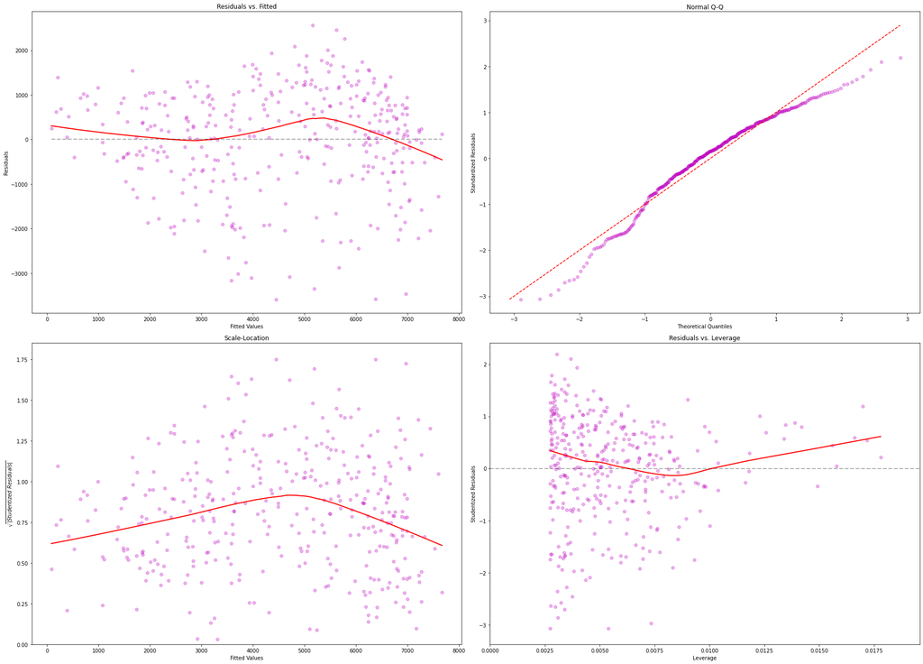

```python
reg_diag_plot(ps_female_2014, edgecolor='m', facecolor='m', alpha=0.3)
```

Die Plots sehen etwas anders oder ähnlich aus wie im ersten Modell.

- Im ersten Plot sind die Werte nun vermehrt oberhalb von 0, aber die rote Kurve ist ähnlich bis zur Ausnahme das sie am Anfang sinkt.
- Im Q-Q Plot ist ersichtlich das die Verteilung auch nicht ganz der Normalverteilung entspricht.
- Unten links im Plot ist auch wieder eine Steigung drin die dann aber gegen Ende absinkt. Heisst die Varianz der Residuen nimmt gegen ende wieder ab.
- Und im 4. Plot gibt es auch keine sehr auffälligen Werte in der rechten oberen oder unteren Ecke.